# P1-Stroop-Effect

### Background Information

In a Stroop task, participants are presented with a list of words, with each word displayed in a color of ink. The participant’s task is to say out loud the color of the ink in which the word is printed. The task has two conditions: a congruent words condition, and an incongruent words condition. In the congruent words condition, the words being displayed are color words whose names match the colors in which they are printed: for example RED, BLUE. In the incongruent words condition, the words displayed are color words whose names do not match the colors in which they are printed: for example PURPLE, ORANGE. In each case, we measure the time it takes to name the ink colors in equally-sized lists. Each participant will go through and record a time from each condition.

### Questions For Investigation

As a general note, be sure to keep a record of any resources that you use or refer to in the creation of your project. You will need to report your sources as part of the project submission.

#### 1. What is our independent variable? What is our dependent variable?

The independent variable in this case would be the two conditions, congruent and incongruent. The dependent variable is the time taken to name the ink colors

#### 2. What is an appropriate set of hypotheses for this task? Justify your choices.

Given that I havent been able to use the math capabilities of markdown in jupyter i have stablished the variables bellow to indicate the means, which will be used throughout this project

##### mu_c = the mean of the population times for the congruent tasks

##### mu_i = the mean of the population times for the incongruent tasks

##### H_0 = to indicate the null hypothesis

##### H_A = to indicate the alternate hypothesis

The null hypothesis could be the fact that the mean of the population times will remain the same between the congruent and incongruent or that the congruent population time means could be bigger than the mean of the population times for the incongruent tasks

H_0 => mu_c >= mu_i

The alternative hypothesis could be the fact that the mean population time of the incongruent will be longer than the mean population time of the congruent.

H_A => mu_c < mu_i

These hypothesis will be tested through the use of the sample population means.

#### 2b. What kind of statistical test do you expect to perform?

The statistical test to perform is a t-test due to the following reasons:

1. Our sample size is less than 30
2. We do not have the population standard deviation We will use t-test with paired samples given the fact that the subjects perform both tasks

```python
import pandas as pd

# pandas is a software library for data manipulation and analysis
# We commonly use shorter nicknames for certain packages. Pandas is often abbreviated to pd.
# hit shift + enter to run this cell or block of code
```

```python
path = r'~/Downloads/stroopdata.csv'
# Change the path to the location where the chopstick-effectiveness.csv file is located on your computer.
# If you get an error when running this block of code, be sure the chopstick-effectiveness.csv is located at the path on your computer.

dataFrame = pd.read_csv(path)
dataFrame
```

|  | Congruent | Incongruent |
| --- | --- | --- |
| 0 | 12.079 | 19.278 |
| 1 | 16.791 | 18.741 |
| 2 | 9.564 | 21.214 |
| 3 | 8.630 | 15.687 |
| 4 | 14.669 | 22.803 |
| 5 | 12.238 | 20.878 |
| 6 | 14.692 | 24.572 |
| 7 | 8.987 | 17.394 |
| 8 | 9.401 | 20.762 |
| 9 | 14.480 | 26.282 |
| 10 | 22.328 | 24.524 |
| 11 | 15.298 | 18.644 |
| 12 | 15.073 | 17.510 |
| 13 | 16.929 | 20.330 |
| 14 | 18.200 | 35.255 |
| 15 | 12.130 | 22.158 |
| 16 | 18.495 | 25.139 |
| 17 | 10.639 | 20.429 |
| 18 | 11.344 | 17.425 |
| 19 | 12.369 | 34.288 |
| 20 | 12.944 | 23.894 |
| 21 | 14.233 | 17.960 |
| 22 | 19.710 | 22.058 |
| 23 | 16.004 | 21.157 |

#### 3. Report some descriptive statistics regarding this dataset. Include at least one measure of central tendency and at least one measure of variability.

```python
#mean of the congruent tasks
meanCog = dataFrame['Congruent'].mean()
dataFrame['Congruent'].mean()
```

```
14.051125000000004
```

```python
#standard deviation of the sample for Congruent tasks
dataFrame['Congruent'].std()
```

```
3.559357957645195
```

```python
#mean of the incongruent tasks
meanIncog = dataFrame['Incongruent'].mean()
dataFrame['Incongruent'].mean()
```

```
22.01591666666667
```

```python
#standard deviation of the sample for Incongruent tasks
dataFrame['Incongruent'].std()
```

```
4.797057122469138
```

#### 4. Provide one or two visualizations that show the distribution of the sample data. Write one or two sentences noting what you observe about the plot or plots.

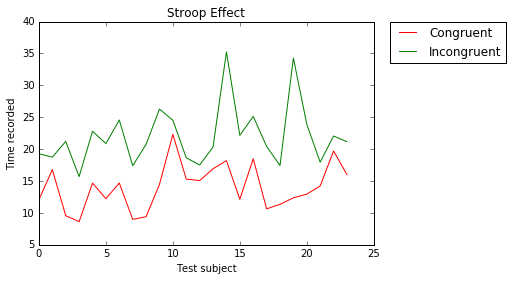

```python
# Causes plots to display within the notebook rather than in a new window
%pylab inline

import matplotlib.pyplot as plt

plt.plot(dataFrame['Congruent'],'r',dataFrame['Incongruent'], 'g')
            # title=""
plt.xlabel("Test subject")
plt.ylabel("Time recorded")
plt.title("Stroop Effect")
plt.legend(["Congruent", "Incongruent"], bbox_to_anchor=(1.05, 1), loc=2, borderaxespad=0.)
plt.show()
```

Here we can see the distribution of the data. We can easilly stablish that the time recorded for the incongruent tasks is bigger than the congruent tasks in every case

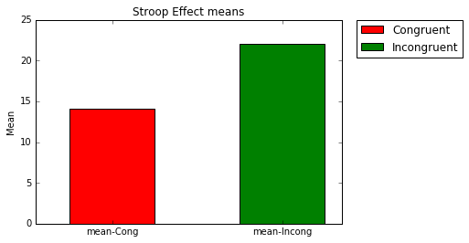

```python
width = 0.5
fig, ax = plt.subplots()
ax.bar(1,meanCog, width, color='r')
ax.bar(2,meanIncog, width, color='g')
ax.set_xticks((1.25,2.25))
ax.set_ylabel('Mean')
ax.set_title('Stroop Effect means')
ax.set_xticklabels(("mean-Cong", "mean-Incong"))
plt.legend(["Congruent", "Incongruent"], bbox_to_anchor=(1.05, 1), loc=2, borderaxespad=0.)
plt.show()
```

Here Its even easier to see the diferences in the mean between the Incongruent and the Congruent tasks. This give some insight about the decision on rejecting the null or not.

#### 5. Now, perform the statistical test and report your results. What is your confidence level and your critical statistic value? Do you reject the null hypothesis or fail to reject it? Come to a conclusion in terms of the experiment task. Did the results match up with your expectations?

Degrees of freedom = 23

We are going to stablish a **one-tail** test at alpha = 0.05

First we subtratct one sample from another so we cam make calculations as if were one sample

sample average = 7.96

Standard deviation of the sample = 4.86

Finally we calculate our t-score = 8.02

T-critical = 1.714

Given the fact that our t-value falls in the critical region we reject the Null hypothesys. This means that, as we expected seening the previous graphs, a human can do Congruent tasks faster that Incongruent ones. This result was totally expected for me given that i took the test before starting this project and the difference in my times was quite considerably.

#### 6. Optional: What do you think is responsible for the effects observed? Can you think of an alternative or similar task that would result in a similar effect? Some research about the problem will be helpful for thinking about these two questions!

In the case of the Congruent tasks the brain just processes the text and gives and answer. However in Incongruent tasks the brain hast to process the text and the color separately given the fact that they are not correlated. This is due to the semantic interference generated between the text and the ink. The study also show that a semantic facilitation exists, indicating that the identification of the color of the ink is much faster when the text and the ink specify the same color.[more info](https://en.wikipedia.org/wiki/Stroop_effect)

There has been different side experiments like the Reverse Stroop Effect developed by Frank H. Durgin from Swarthmore College. Which showed similar results as cam be seen here [paper](http://www.swarthmore.edu/SocSci/fdurgin1/ReverseStroop/PBRStroop.html)

### Resources

Pyplot visualization : http://matplotlib.org/users/pyplot_tutorial.html

Pyplot Bar : http://matplotlib.org/examples/api/barchart_demo.html

Stroop Effect : https://en.wikipedia.org/wiki/Stroop_effect

Reverse Stroop : http://www.swarthmore.edu/SocSci/fdurgin1/ReverseStroop/PBRStroop.html